# Simulating Exponentials

## Sample Means Normally Distrubted

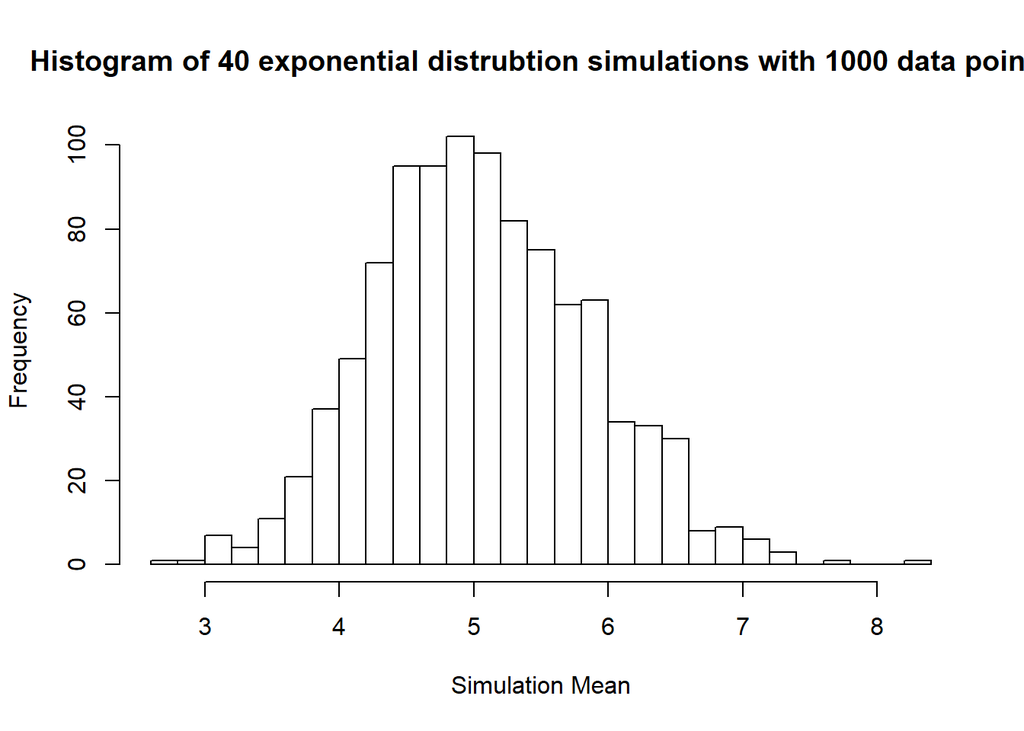

```r
hist(means,
     breaks = 20,
     main = paste("Histogram of", B, "exponential distrubtion simulations with",n,"data points"),
     xlab = "Simulation Mean")
```

We can tell thi from the tell tale bell curve shape centered at approximatly the theoretical mean of **5** which thins out at the tails.

# Analysing Tooth Growth Data

## Exploratory Data Analysis

We begin by loading the ToothGrowth data from the R datasets package.

```r
library(datasets) # load data sets
toothData <- ToothGrowth # load Tooth Growth Dataset
```

## Summary

Let’s have a look at the dimensions of the dataset first.

```r
dims <- dim(toothData)
```

The dataset consts of 60 observations and 3 variables. Let’s have a look at the variables next.

```r
str(toothData)
```

```
## 'data.frame':    60 obs. of  3 variables:
##  $ len : num  4.2 11.5 7.3 5.8 6.4 10 11.2 11.2 5.2 7 ...
##  $ supp: Factor w/ 2 levels "OJ","VC": 2 2 2 2 2 2 2 2 2 2 ...
##  $ dose: num  0.5 0.5 0.5 0.5 0.5 0.5 0.5 0.5 0.5 0.5 ...
```

We see there is a numeric len, 2 factors for supp as either “OJ” or “VC”. And a dose.

```r
head(toothData)
```

```
##    len supp dose
## 1  4.2   VC  0.5
## 2 11.5   VC  0.5
## 3  7.3   VC  0.5
## 4  5.8   VC  0.5
## 5  6.4   VC  0.5
## 6 10.0   VC  0.5
```

Having a quick look at the doses which are listed as a numeric.

```r
table(toothData$dose)
```

```
##
## 0.5   1   2
##  20  20  20
```

But in fact we only see one of 3 options, 0.5, 1, or 2. And each appears 20 times.

Next let’s look at each group seperately on the same plot.

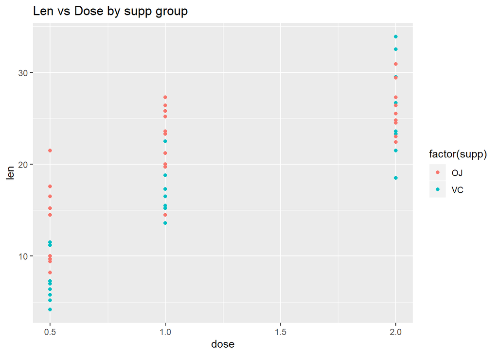

```r
library(ggplot2)
g <- ggplot(toothData, aes(dose,len))
g + geom_point(aes(color=factor(supp))) + labs(title = "Len vs Dose by supp group")
```

```r
splitTooth <- split(toothData, toothData$supp)
OJmean <- mean(splitTooth$OJ$len)
VCmean <- mean(splitTooth$VC$len)
meanDiff <- OJmean-VCmean
```

Looking at the means of both (averaged across all doses) we see

- OJ had a mean of **20.66**
- VC hada mean of **16.96**

And the difference between the two is that OJ was **3.7** larger than VC